# Linear time series models and the algebra of ARMA models

Edward Ionides

1/18/2016

Licensed under the Creative Commons attribution-noncommercial license, http://creativecommons.org/licenses/by-nc/3.0/. Please share and remix noncommercially, mentioning its origin.

Objectives

1. Putting autoregressive moving average (ARMA) models into the context of linear time series models.
2. Introduce the backshift operator, and see how it can be used to develop an algebraic approach to studying the properties of ARMA models.

## 4.1 Definition: Stationary causal linear process.

- A **stationary causal linear process** is a time series models that can be written as  
  [M7] ${\quad\quad\quad}X_n = \mu + g_0\epsilon_n + g_1\epsilon_{n-1}+g_2\epsilon_{n-2}+g_3\epsilon_{n-3} + g_4\epsilon_{n-4}+\dots$  
  where $\{\epsilon_n, n=\dots,-2,-1,0,1,2,\dots\}$ is a white noise process, defined for all integer timepoints, with variance ${\mathrm{Var}}(\epsilon_n)=\sigma^2$.
- We do not need to define any initial values. The doubly infinite noise process $\{\epsilon_n, n=\dots,-2,-1,0,1,2,\dots\}$ is enough to define $X_n$ for every $n$ as long as the sequence in [M7] converges.
- **stationary** since the construction is the same for each $n$.

### 4.1.1 Question: When does the “stationary” here mean weak stationarity, and when does it mean strict stationary?

- **causal** refers to $\{\epsilon_n\}$ being a causal driver of $\{X_n\}$. The value of $X_n$ depends only on noise process values already determined by time $n$. This matching a [requirement for causation](https://en.wikipedia.org/wiki/Bradford_Hill_criteria) that causes must precede effects.
- **linear** refers to linearity of $X_n$ as a function of $\{\epsilon_n\}$. A linear modification of the noise process, replacing $\{\epsilon_n\}$ by $\{\alpha + \beta\epsilon_n\}$, results in a new linear process.
- The autocovariance function is, $\begin{eqnarray} \gamma_h &=& {\mathrm{Cov}}\big(X_n,X_{n+h}\big)\\ &=& {\mathrm{Cov}}\left(\sum_{j=0}^\infty g_j\epsilon_{n-j},\sum_{k=0}^\infty g_k\epsilon_{n+h-k}\right)\\ &=& \sum_{j=0}^\infty \sum_{k=0}^\infty g_j g_k{\mathrm{Cov}}\big(\epsilon_{n-j},\epsilon_{n+h-k}\big)\\ &=& \sum_{j=0}^\infty g_jg_{j+h} \sigma^2, \mbox{for $h\ge 0$}. \end{eqnarray}$
- In order for this autocovariance function to exist, we need $\sum_{j=0}^\infty g_j^2 < \infty.$ We may also require a stronger condition, $\sum_{j=0}^\infty |g_j| < \infty.$
- The MA(q) model that we defined in equation [M3] is an example of a stationary, causal linear process.
- The general stationary, causal linear process model [M7] can also be called the MA($\infty$) model.

## 4.2 The backshift operator and the difference operator

- The **backshift** operator $B$, also known as the **lag** operator, is given by $B X_n = X_{n-1}.$
- The **difference** operator $\Delta=1-B$ is $\Delta X_n = (1-B)X_n = X_n - X_{n-1}.$
- Powers of the backshift operator correspond to different time shifts, e.g., $B^2 X_n = B (BX_n) = B(X_{n-1}) = X_{n-2}.$
- We can also take a second difference, $\begin{eqnarray} \Delta^2 X_n &=& (1-B)(1-B) X_n\\ &=& (1-2B+B^2) X_n = X_n - 2X_{n-1} + X_{n-2}. \end{eqnarray}$
- The backshift operator is linear, i.e., $(\alpha +\beta B)X_n = \alpha X_n + \beta BX_n = \alpha X_n + \beta X_{n-1}.$
- The AR, MA and linear process model equations can all be written in terms of polynomials in the backshift operator.
- Write ${\phi}(x)$ for a polynomial of order $p$, ${\phi}(x) = 1-{\phi}_1 x -{\phi}_2 x^2 -\dots -{\phi}_p x^p.$ The equation M1 for the AR(p) model can be rearranged to give $X_n - {\phi}_1 X_{n-1}- {\phi}_2X_{n-2}-\dots-{\phi}_pX_{n-p} = \epsilon_n,$ which is equivalent to  
  [M1$^\prime$] ${\quad\quad\quad}{\phi}(B) X_n = \epsilon_n$.
- Similarly, writing ${\psi}(x)$ for a polynomial of order $q$, ${\psi}(x) = 1+{\psi}_1 x +{\psi}_2 x^2 + \dots +{\psi}_q x^q,$ the MA(q) equation M3 is equivalent to  
  [M3$^\prime$] ${\quad\quad\quad}X_n = {\psi}(B) \epsilon_n$.
- Additionally, if $g(x)$ is a function defined by the [Taylor series](https://en.wikipedia.org/wiki/Taylor_series) expansion $g(x)= g_0 + g_1 x + g_2 x^2 + g_3 x^3 + g_4 x^4 + \dots,$ we can write the stationary causal linear process equation [M7] as  
  [M7$^\prime$] ${\quad\quad\quad}X_n = \mu + g(B)\epsilon_n$.
- Whatever skills you have acquired, or acquire during this course, about working with [Taylor series](https://en.wikipedia.org/wiki/Taylor_series) expansions will help you understand AR and MA models, and ARMA models that combine both autoregressive and moving average features.

## 4.3 The general ARMA model

- Putting together M1 and M3 suggests an **autoregressive moving average** ARMA(p,q) model given by  
  [M9] ${\quad\quad\quad}X_n = {\phi}_1 X_{n-1}+{\phi}_2X_{n-2}+\dots+{\phi}_pX_{n-p} + \epsilon_n +{\psi}_1 \epsilon_{n-1} +\dots+{\psi}_q\epsilon_{n-q}$,  
  where $\{\epsilon_n\}$ is a white noise process. Using the backshift operator, we can write this more succinctly as  
  [M9$^\prime$] ${\quad\quad\quad}{\phi}(B) X_n = {\psi}(B) \epsilon_n$.
- Experience with data analysis suggests that models with both AR and MA components often fit data better than a pure AR or MA process.

### 4.3.1 Exercise: Carry out the following steps to obtain the MA($\infty$) representation and the autocovariance function of the ARMA(1,1) model,

$X_n = {\phi}X_{n-1} + \epsilon_n + {\psi}\epsilon_{n-1}.$

1. Formally, we can write $(1-{\phi}B)X_n = (1+{\psi}B)\epsilon_n,$ which algebraically is equivalent to $X_n = \left(\frac{1+{\psi}B}{1-{\phi}B}\right)\epsilon_n.$ We write this as $X_n = g(B) \epsilon_n,$ where $g(x) = \left(\frac{1+{\psi}x}{1-{\phi}x}\right).$ To make sense of $g(B)$ we need to work out the [Taylor series](https://en.wikipedia.org/wiki/Taylor_series) expansion, $g(x) = g_0 + g_1 x + g_2 x^2 + g_3 x^3 + \dots$ Do this either by hand or using your favorite math software.
2. From 1. we can get the MA($\infty$) representation. Then, we can apply the general formula for the autocovariance function of an MA($\infty$) process.

## 4.4 Causal, invertible ARMA models

- We say that the ARMA model [M9] is **causal** if its MA($\infty$) representation is a convergent series.
- Recall that **causality** is about writing $X_n$ in terms of the driving noise process $\{\epsilon_n,\epsilon_{n-1},\epsilon_{n-2},\dots\}$.
- **Invertibility** is about writing $\epsilon_n$ in terms of $\{X_n, X_{n-1}, X_{n-2},\dots\}$.
- To assess causality, we consider the convergence of the Taylor series expansion of ${\psi}(x)/{\phi}(x)$ in the ARMA representation $X_n = \frac{{\psi}(B)}{{\phi}(B)} \epsilon_n.$
- To assess invertibility, we consider the convergence of the Taylor series expansion of ${\phi}(x)/{\psi}(x)$ in the inversion of the ARMA model given by $\epsilon_n = \frac{{\phi}(B)}{{\psi}(B)} X_n.$
- Fortunately, there is a simple way to check causality and invertibility. We will state the result without proof.
  - The ARMA model is causal if the AR polynomial, ${\phi}(x) = 1-{\phi}_1 x - {\phi}_2 x^2 - \dots - {\phi}_p x^p$ has all its roots (i.e., solutions to ${\phi}(x)=0$) outside the unit circle in the complex plane.
  - The ARMA model is invertible if the MA polynomial, ${\psi}(x) = 1+{\psi}_1 x + {\psi}_2 x^2 + \dots + {\psi}_q x^q$ has all its roots (i.e., solutions to ${\psi}(x)=0$) outside the unit circle in the complex plane.
- We can check the roots using the `polyroot` function in R. For example, consider the MA(2) model, $X_n = \epsilon_n + 2\epsilon_{n-1} + 2\epsilon_{n-2}.$ The roots to ${\psi}(x)= 1+2x+2x^2$ are

```r
roots <- polyroot(c(1,2,2))
roots
```

```
## [1] -0.5+0.5i -0.5-0.5i
```

Finding the absolute value shows that we have two roots inside the unit circle, so this MA(2) model is not invertible.

```r
abs(roots)
```

```
## [1] 0.7071068 0.7071068
```

- In this case, you should be able to find the roots algebraically. In general, numerical evaluation of roots is useful.

### 4.4.1 Question: It is undesirable to use a non-invertible model for data analysis. Why?

One answer to this question involves diagnosing model misspecification.

## 4.5 Reducible and irreducible ARMA models

```r
list(AR_roots=polyroot(c(1,-5/6,1/6)),MA_roots=polyroot(c(1,-1,1/4)))
```

```
## $AR_roots
## [1] 2+0i 3+0i
##
## $MA_roots
## [1] 2+0i 2-0i
```

## 4.6 Deterministic skeletons: Using differential equations to study ARMA models

- Non-random physical processes evolving through time have been modeled using differential equations ever since the ground-breaking work by [Newton(1687)](https://en.wikipedia.org/wiki/Philosophi%C3%A6_Naturalis_Principia_Mathematica).
- We have to attend to the considerable amount of randomness (almost equivalent to unpredictability) that is often present in data and systems we want to study.
- However, we want to learn a little bit from the extensive study of deterministic systems.
- The **deterministic skeleton** of a time series model is the non-random process obtained by removing the randomness from a stochastic model.
- If the time series model is discrete-time, one may also define a continuous-time deterministic skeleton by replacing the discrete-time difference equation with a differential equation.
- Sometimes, rather than deriving a deterministic skeleton from a stochastic time series model, we work in reverse: we add stochasticity to a deterministic model in order to obtain a model that can explain non-deterministic phenomena.

### 4.6.1 Example: oscillatory behavior modeled using an AR(2) process

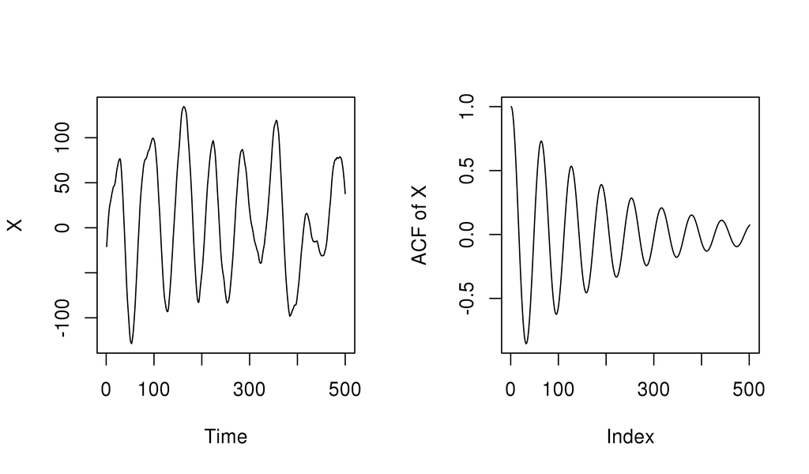

```r
omega <- 0.1
ar_coefs <- c(2/(1+omega^2), - 1/(1+omega^2))
set.seed(8395200)
X <- arima.sim(list(ar=ar_coefs),n=500,sd=1)
par(mfrow=c(1,2))
plot(X)
plot(ARMAacf(ar=ar_coefs,lag.max=500),type="l",ylab="ACF of X")
```

- Quasi-periodic fluctuations are said to be “phase locked” as long as the random peturbations are not able to knock the oscillations away from being close to their initial phase.
- Eventually, the randomness should mean that the process is equally likely to have any phase, regardless of the initial phase.

### 4.6.2 Question: What is the timescale on which the simulated model shows phase locked behavior?

- Equivalently, on what timescale does the phase of the fluctuations lose memory of its initial phase?